# Classifying Physical Activity

The 19 activites are as follows:

1)sitting,

2)standing,

3)lying on back,

4)lying on right side,

5)ascending stairs,

6)descending stairs,

7)standing in an elevator still,

8)moving around in an elevator,

9)walking in a parking lot,

10)walking on a treadmill with a speed of 4 km/h no incline,

11)walking on a treadmill with a speed of 4 km/h with 15 deg incline,

12)running on a treadmill with a speed of 8 km/h,

13)exercising on a stepper,

14)exercising on a cross trainer,

15)cycling on an exercise bike in horizontal position,

16)cycling on an exercise bike in vertical position,

17)rowing,

18)jumping,

19)playing basketball.

## Data Exploration

```python
patients = [df19p1, df18p1, df17p1, df16p1, df15p1, df14p1, df13p1, df12p1, df11p1, df10p1, df11p1, df10p1,
            df09p1, df08p1, df07p1, df06p1, df05p1, df04p1, df03p1, df02p1, df01p1, df19p2, df18p2, df17p2,
            df16p2, df15p2, df14p2, df13p2, df12p2, df11p2, df10p2, df11p2, df10p2, df09p2, df08p2, df07p2,
            df06p2, df05p2, df04p2, df03p2, df02p2, df01p2, df19p3, df18p3, df17p3, df16p3, df15p3, df14p3,
            df13p3, df12p3, df11p3, df10p3, df11p3, df10p3, df09p3, df08p3, df07p3, df06p3, df05p3, df04p3,
            df03p3, df02p3, df01p3, df19p4, df18p4, df17p4, df16p4, df15p4, df14p4, df13p4, df12p4, df11p4,
            df10p4, df11p4, df10p4, df09p4, df08p4, df07p4, df06p4, df05p4, df04p4, df03p4, df02p4, df01p4,
            df19p5, df18p5, df17p5, df16p5, df15p5, df14p5, df13p5, df12p5, df11p5, df10p5, df11p5, df10p5,
            df09p5, df08p5, df07p5, df06p5, df05p5, df04p5, df03p5, df02p5, df01p5, df19p6, df18p6, df17p6,
            df16p6, df15p6, df14p6, df13p6, df12p6, df11p6, df10p6, df11p6, df10p6, df09p6, df08p6, df07p6,
            df06p6, df05p6, df04p6, df03p6, df02p6, df01p6, df19p7, df18p7, df17p7, df16p7, df15p7, df14p7,
            df13p7, df12p7, df11p7, df10p7, df11p7, df10p7, df09p7, df08p7, df07p7, df06p7, df05p7, df04p7,
            df03p7, df02p7, df01p7, df19p8, df18p8, df17p8, df16p8, df15p8, df14p8, df13p8, df12p8, df11p8,
            df10p8, df11p8, df10p8, df09p8, df08p8, df07p8, df06p8, df05p8, df04p8, df03p8, df02p8, df01p8]

result = pd.concat(patients)

result.head(130)
```

|  | T_xacc | T_yacc | T_zacc | T_xgyro | T_ygyro | T_zgyro | T_xmag | T_ymag | T_zmag | RA_xacc | ... | LL_yacc | LL_zacc | LL_xgyro | LL_ygyro | LL_zgyro | LL_xmag | LL_ymag | LL_zmag | activity | patient |
| --- | --- | --- | --- | --- | --- | --- | --- | --- | --- | --- | --- | --- | --- | --- | --- | --- | --- | --- | --- | --- | --- |
| 0 | 6.1990 | -1.961400 | 4.52760 | 0.015272 | -1.431600 | -0.533980 | -0.35629 | 0.151970 | -0.87986 | 0.93413 | ... | 2.884400 | 1.082400 | -1.548500 | 0.284850 | 1.092600 | 0.84818 | 0.49408 | 0.147010 | 19 | 1 |
| 1 | 6.4366 | -2.185300 | 4.46830 | 1.039600 | -2.256300 | 0.020906 | -0.43659 | 0.124180 | -0.84997 | 7.44070 | ... | 2.194400 | 1.279300 | -1.189700 | 0.372430 | 1.219800 | 0.87077 | 0.44356 | 0.185280 | 19 | 1 |
| 2 | 6.8567 | -0.527490 | 0.27479 | 0.966900 | -1.622000 | 1.005600 | -0.49428 | 0.095069 | -0.81655 | 8.50120 | ... | 1.925500 | 0.779670 | -1.151500 | 0.206440 | 1.228200 | 0.89248 | 0.39384 | 0.220600 | 19 | 1 |
| 3 | 9.1399 | -1.727100 | 3.00720 | 0.739090 | -0.218050 | -0.169540 | -0.49868 | 0.062652 | -0.81847 | 3.33800 | ... | 4.982100 | 0.609900 | -0.434280 | 0.321560 | 1.378400 | 0.90996 | 0.34194 | 0.246350 | 19 | 1 |
| 4 | 11.9520 | -1.750400 | 5.06500 | -0.164310 | -2.669700 | -0.279320 | -0.55689 | 0.054494 | -0.78178 | 4.19170 | ... | -14.468000 | -4.206300 | 2.277000 | 0.719140 | 0.454690 | 0.92423 | 0.30114 | 0.251900 | 19 | 1 |
| 5 | 13.6720 | -2.931700 | 6.20430 | 1.058400 | -2.219900 | -0.233800 | -0.65630 | 0.036932 | -0.71593 | 3.47200 | ... | -8.012400 | -0.487750 | 1.317600 | 2.370400 | -1.436700 | 0.89656 | 0.35730 | 0.286210 | 19 | 1 |
| 6 | 13.0940 | -2.635200 | 5.45580 | 1.363700 | -1.218000 | 0.359570 | -0.69980 | 0.001784 | -0.67637 | -0.81867 | ... | 5.246600 | 1.460100 | -1.126000 | 0.057297 | -0.680420 | 0.86063 | 0.39589 | 0.348890 | 19 | 1 |
| 7 | 9.8232 | -1.986300 | 3.48070 | 3.522600 | 0.390050 | 0.234820 | -0.71096 | -0.051835 | -0.65447 | -4.25720 | ... | -4.347500 | -2.321100 | -1.092600 | 0.098984 | -0.564560 | 0.85396 | 0.39683 | 0.369870 | 19 | 1 |
| 8 | 10.3200 | -1.254200 | 2.78800 | 2.391300 | 0.388510 | 0.760450 | -0.71261 | -0.114530 | -0.64524 | -7.29850 | ... | -0.971350 | -3.602200 | -0.636850 | 1.061100 | -0.918040 | 0.83366 | 0.41495 | 0.398920 | 19 | 1 |
| 9 | 11.3610 | -0.560430 | 5.06080 | 2.484700 | 0.208530 | 0.405920 | -0.70174 | -0.166370 | -0.64604 | -10.21600 | ... | 5.623200 | -0.321570 | -1.688800 | -0.157480 | -0.360980 | 0.81486 | 0.41995 | 0.436950 | 19 | 1 |
| 10 | 8.8796 | -0.469300 | 2.05110 | 1.375600 | -0.225570 | 0.590100 | -0.70407 | -0.207140 | -0.63645 | -9.31760 | ... | 0.742640 | -1.697300 | -1.294300 | 0.049982 | -0.350250 | 0.82048 | 0.38513 | 0.451740 | 19 | 1 |
| 11 | 7.5027 | -1.401600 | 2.69110 | 1.456600 | -0.440840 | 0.428670 | -0.72361 | -0.222430 | -0.60959 | -8.18130 | ... | 1.267000 | -1.553500 | -0.885570 | 0.270060 | -0.360470 | 0.81230 | 0.37625 | 0.473770 | 19 | 1 |
| 12 | 7.1677 | -0.195010 | 1.72660 | 1.805400 | -0.019856 | 0.266780 | -0.73532 | -0.245080 | -0.58714 | -6.75300 | ... | 2.252700 | -2.176700 | -0.936850 | 0.203210 | -0.107820 | 0.80132 | 0.37868 | 0.499190 | 19 | 1 |
| 13 | 7.7535 | 0.925370 | 1.94720 | 1.506300 | 0.546960 | 0.109010 | -0.73456 | -0.274120 | -0.57369 | -6.50530 | ... | 2.051700 | -2.474800 | -1.416100 | 0.197980 | 0.030771 | 0.79590 | 0.35490 | 0.525530 | 19 | 1 |
| 14 | 8.4380 | 1.579900 | 3.61280 | 0.350120 | 0.620820 | 0.296980 | -0.72136 | -0.290680 | -0.58417 | -5.78900 | ... | -1.775900 | -0.612560 | -1.377600 | 0.093512 | 0.190410 | 0.79413 | 0.31993 | 0.549440 | 19 | 1 |
| 15 | 9.1189 | 1.412600 | 5.21330 | -0.123080 | 0.317570 | -0.028714 | -0.71378 | -0.293700 | -0.59814 | -4.25220 | ... | -3.551100 | -0.614870 | -0.420260 | -0.129100 | 0.099345 | 0.79792 | 0.28765 | 0.555820 | 19 | 1 |
| 16 | 9.1171 | 0.622890 | 4.47700 | -0.526380 | -0.024522 | -0.135470 | -0.70797 | -0.288090 | -0.60536 | -5.25980 | ... | -3.704400 | -2.405800 | 0.041987 | -0.017164 | -0.118400 | 0.80344 | 0.28653 | 0.555220 | 19 | 1 |
| 17 | 8.4458 | -0.152320 | 3.31810 | -0.839210 | -0.159720 | -0.394470 | -0.70927 | -0.274140 | -0.60696 | -4.36910 | ... | -1.210200 | -2.057300 | 0.274410 | 0.126400 | -0.063791 | 0.79843 | 0.29534 | 0.558720 | 19 | 1 |
| 18 | 9.3254 | -1.232400 | 1.18410 | -0.930750 | 0.784680 | -0.719730 | -0.70141 | -0.265520 | -0.62285 | -2.98050 | ... | -0.267790 | -1.800700 | 0.682720 | 0.167860 | 0.044185 | 0.79613 | 0.30603 | 0.558050 | 19 | 1 |
| 19 | 10.0760 | 0.126270 | 4.48110 | -1.399900 | -0.280450 | -0.804880 | -0.67825 | -0.261570 | -0.64632 | -1.39180 | ... | 0.312430 | -1.687200 | 0.997070 | 0.000159 | 0.118960 | 0.79775 | 0.32312 | 0.547120 | 19 | 1 |
| 20 | 10.2000 | -0.696110 | 4.26780 | -1.132500 | 0.020253 | -0.690010 | -0.67871 | -0.249430 | -0.65224 | 6.87590 | ... | 1.645300 | -1.628800 | 0.809630 | 0.091824 | 0.112170 | 0.79732 | 0.34387 | 0.534080 | 19 | 1 |
| 21 | 9.4942 | -0.679140 | 3.28530 | -1.416800 | 0.721880 | -0.477390 | -0.66866 | -0.225590 | -0.67106 | 9.46210 | ... | 1.999100 | -1.219800 | 0.618920 | 0.059274 | 0.188060 | 0.79915 | 0.35283 | 0.526330 | 19 | 1 |
| 22 | 8.3329 | -0.704690 | 2.73920 | -0.653990 | 1.195000 | -0.600740 | -0.64070 | -0.220750 | -0.69620 | 12.39400 | ... | 0.805710 | -1.111400 | 0.166520 | 0.049007 | 0.200220 | 0.79937 | 0.35075 | 0.525330 | 19 | 1 |
| 23 | 6.8393 | -1.099600 | 6.34340 | -0.387920 | 0.421420 | -0.713760 | -0.60962 | -0.219170 | -0.72464 | 15.62800 | ... | -0.037518 | -2.252900 | 0.025721 | 0.078085 | 0.031340 | 0.80190 | 0.34932 | 0.527280 | 19 | 1 |
| 24 | 8.0668 | 0.002216 | 6.20320 | -1.398600 | -0.507690 | -0.067135 | -0.61342 | -0.203030 | -0.72608 | 21.74300 | ... | 0.670930 | -1.420400 | 0.226850 | 0.100800 | 0.095364 | 0.80146 | 0.35035 | 0.528560 | 19 | 1 |
| 25 | 8.3135 | -1.900300 | 5.39450 | -1.414300 | -1.164000 | 0.353280 | -0.62020 | -0.173190 | -0.72867 | 13.87600 | ... | 2.040800 | -1.832900 | 0.003640 | 0.144240 | 0.063721 | 0.79971 | 0.34798 | 0.529470 | 19 | 1 |
| 26 | 10.1760 | -4.306400 | 1.28250 | 0.987070 | 0.487900 | 0.384000 | -0.63872 | -0.151080 | -0.71896 | 9.94880 | ... | 2.697800 | -1.719200 | -0.281220 | 0.100310 | 0.159080 | 0.79915 | 0.34165 | 0.535230 | 19 | 1 |
| 27 | 8.8929 | -0.991460 | 4.80060 | 1.399800 | 0.107700 | 0.534100 | -0.63364 | -0.171420 | -0.71836 | 5.35490 | ... | 1.052900 | -1.806700 | -0.548390 | 0.084960 | 0.163140 | 0.79944 | 0.33010 | 0.542570 | 19 | 1 |
| 28 | 7.9325 | -0.474890 | 5.37110 | 1.292000 | -0.804980 | 0.743940 | -0.65541 | -0.187320 | -0.69634 | 4.72060 | ... | 1.735000 | -1.827900 | -0.655920 | 0.118140 | 0.177380 | 0.79941 | 0.31250 | 0.553430 | 19 | 1 |
| 29 | 9.1003 | -0.365510 | 3.44850 | 0.717140 | -0.340080 | 0.635390 | -0.68225 | -0.195200 | -0.66757 | 5.41700 | ... | 0.372510 | -1.378300 | -0.526320 | -0.041711 | 0.230190 | 0.80223 | 0.29183 | 0.561280 | 19 | 1 |
| ... | ... | ... | ... | ... | ... | ... | ... | ... | ... | ... | ... | ... | ... | ... | ... | ... | ... | ... | ... | ... | ... |
| 100 | 9.8994 | -1.270900 | 4.09070 | -0.422560 | -0.203170 | -0.032455 | -0.61066 | -0.077840 | -0.76289 | -2.86200 | ... | 1.555400 | 0.102010 | 0.248420 | -0.010467 | -0.093413 | 0.94576 | 0.31850 | 0.339140 | 19 | 1 |
| 101 | 8.8872 | -1.562300 | 3.02920 | -0.249960 | -0.331640 | -0.059190 | -0.62145 | -0.068450 | -0.75703 | -3.20040 | ... | 2.971000 | 0.040668 | -0.285900 | -0.012321 | -0.097253 | 0.94266 | 0.32185 | 0.340690 | 19 | 1 |
| 102 | 8.7851 | -1.204900 | 2.77710 | -0.079324 | -0.078285 | -0.054585 | -0.62351 | -0.070115 | -0.75101 | -2.98540 | ... | 0.961660 | -0.034333 | -0.362610 | -0.110470 | -0.040488 | 0.94456 | 0.32044 | 0.339330 | 19 | 1 |
| 103 | 8.8898 | -0.910880 | 3.13790 | -0.028289 | 0.000442 | -0.049344 | -0.62486 | -0.070914 | -0.74921 | -2.98630 | ... | 0.470370 | -0.447560 | 0.026332 | 0.009167 | -0.135580 | 0.94371 | 0.32082 | 0.340480 | 19 | 1 |
| 104 | 9.1577 | -0.987200 | 3.16180 | -0.167980 | -0.032415 | -0.036600 | -0.62535 | -0.067230 | -0.74846 | -3.40650 | ... | 2.925700 | -0.311960 | 0.327490 | -0.071081 | -0.010679 | 0.94337 | 0.32686 | 0.336930 | 19 | 1 |
| 105 | 9.8346 | -1.288800 | 3.12770 | -0.172320 | 0.184630 | -0.039308 | -0.62724 | -0.060503 | -0.75149 | -3.85830 | ... | 2.535500 | -0.166400 | 0.188130 | -0.134590 | 0.068727 | 0.94356 | 0.32652 | 0.330360 | 19 | 1 |
| 106 | 9.7067 | -1.223600 | 3.75380 | -0.166610 | 0.247380 | -0.046845 | -0.61928 | -0.057605 | -0.75808 | -3.83960 | ... | 1.443900 | -0.283970 | -0.119890 | -0.093471 | 0.035300 | 0.94580 | 0.32383 | 0.326260 | 19 | 1 |
| 107 | 8.8417 | -1.482300 | 3.49190 | -0.266760 | 0.120390 | -0.055663 | -0.61360 | -0.052885 | -0.76027 | -4.18650 | ... | 1.883500 | 0.222690 | -0.315830 | -0.217150 | 0.070286 | 0.94871 | 0.32126 | 0.324030 | 19 | 1 |
| 108 | 8.2934 | -0.884540 | 3.30510 | -0.117890 | 0.162750 | -0.084870 | -0.60877 | -0.047998 | -0.76369 | -3.93580 | ... | 0.396190 | -0.353680 | -0.344040 | -0.295510 | 0.018053 | 0.95261 | 0.31456 | 0.316640 | 19 | 1 |
| 109 | 8.5595 | -1.441600 | 3.14690 | -0.118590 | 0.353270 | -0.116700 | -0.60002 | -0.045171 | -0.77277 | -4.11770 | ... | 0.366510 | -0.413530 | 0.032694 | -0.186180 | -0.050883 | 0.95580 | 0.31361 | 0.309380 | 19 | 1 |
| 110 | 9.1771 | -1.257000 | 3.89880 | -0.180230 | 0.401250 | -0.071283 | -0.58891 | -0.041910 | -0.77977 | -4.95850 | ... | 0.128280 | -0.180940 | 0.280490 | -0.207660 | -0.098501 | 0.95617 | 0.31563 | 0.302240 | 19 | 1 |
| 111 | 9.2629 | -0.420500 | 3.87500 | -0.368650 | 0.643940 | 0.015002 | -0.57513 | -0.035635 | -0.79092 | -5.36170 | ... | -0.048532 | 0.134370 | 0.397580 | -0.186620 | -0.152560 | 0.95570 | 0.32538 | 0.292030 | 19 | 1 |
| 112 | 8.0774 | 0.066028 | 5.00310 | -0.597170 | 0.013705 | -0.051044 | -0.56531 | -0.024795 | -0.79961 | -2.39930 | ... | -2.484900 | 0.984920 | 0.605100 | -0.448730 | -0.280980 | 0.95626 | 0.34121 | 0.273580 | 19 | 1 |
| 113 | 6.9953 | -0.325020 | 4.93270 | -0.677620 | 0.445750 | -0.210910 | -0.55251 | -0.003575 | -0.80641 | -1.53370 | ... | -5.198700 | 0.513590 | 1.220900 | -0.166900 | -0.889610 | 0.94871 | 0.37715 | 0.248960 | 19 | 1 |
| 114 | 7.5228 | -2.211600 | 5.13330 | -0.819810 | -0.149210 | -0.277860 | -0.54520 | 0.015125 | -0.81234 | -5.93660 | ... | -2.150000 | 0.486850 | 0.963110 | 0.108840 | -1.341600 | 0.92991 | 0.43080 | 0.232620 | 19 | 1 |
| 115 | 9.7271 | -3.275900 | 3.80030 | 0.190760 | 0.764770 | 0.030697 | -0.53509 | 0.027287 | -0.81799 | -6.32850 | ... | -0.210080 | -1.522800 | 0.488690 | -0.010734 | -1.296500 | 0.90351 | 0.48685 | 0.219150 | 19 | 1 |
| 116 | 8.6832 | -2.253700 | 5.93260 | 0.130050 | -0.568640 | 0.346460 | -0.52812 | 0.023660 | -0.82338 | -4.42230 | ... | 0.760170 | 0.722580 | 0.203510 | 0.406550 | -1.646700 | 0.86883 | 0.54515 | 0.223030 | 19 | 1 |
| 117 | 7.3958 | -2.590800 | 7.60660 | -0.004580 | -0.502810 | 0.084197 | -0.53673 | 0.025354 | -0.81659 | -2.11250 | ... | 1.315900 | 0.651660 | -0.489560 | 0.281310 | -1.407500 | 0.82968 | 0.59668 | 0.235070 | 19 | 1 |
| 118 | 8.4908 | -2.764700 | 4.42090 | -0.091649 | -0.807500 | -0.191910 | -0.56378 | 0.027010 | -0.79648 | -5.90050 | ... | 0.353010 | 2.082200 | -0.315280 | 0.077264 | -1.416600 | 0.79404 | 0.63502 | 0.249300 | 19 | 1 |
| 119 | 9.1010 | -2.594500 | 5.09800 | 0.302720 | 0.554290 | -0.194390 | -0.55779 | 0.014504 | -0.80330 | -8.02420 | ... | -1.189700 | 1.110800 | 0.678580 | -0.096927 | -1.508600 | 0.75737 | 0.68179 | 0.238310 | 19 | 1 |
| 120 | 8.2136 | -2.897200 | 4.77600 | 0.526010 | -0.276670 | 0.018215 | -0.56163 | 0.000722 | -0.80150 | -8.34070 | ... | -1.027300 | 0.926340 | 1.511600 | -0.118520 | -1.569900 | 0.71057 | 0.73701 | 0.204050 | 19 | 1 |
| 121 | 6.9747 | -2.804700 | 2.64860 | 0.480190 | -0.705890 | 0.141070 | -0.58398 | -0.013250 | -0.78533 | -6.84860 | ... | -0.310740 | 0.576170 | 1.370800 | -0.428620 | -1.365600 | 0.66886 | 0.78699 | 0.146340 | 19 | 1 |
| 122 | 6.1380 | -2.272000 | 4.49580 | 0.460320 | -0.184900 | 0.052187 | -0.58679 | -0.029892 | -0.78175 | -5.70370 | ... | -0.233410 | 0.888740 | 0.959890 | -0.303540 | -1.121700 | 0.63298 | 0.82873 | 0.094629 | 19 | 1 |
| 123 | 6.4372 | -1.993200 | 4.55950 | 0.357530 | -0.716180 | -0.062361 | -0.60496 | -0.041083 | -0.76624 | -6.42530 | ... | -1.204500 | 1.134300 | 0.513820 | -0.318680 | -0.971160 | 0.60104 | 0.85611 | 0.063597 | 19 | 1 |
| 124 | 7.6497 | -1.156000 | 3.94750 | 0.415960 | -0.383770 | 0.014838 | -0.62374 | -0.056811 | -0.75257 | -8.56460 | ... | -1.893700 | 1.530300 | 0.349790 | 0.041269 | -0.777530 | 0.57039 | 0.87934 | 0.045857 | 19 | 1 |
| 0 | 7.1787 | -1.931800 | 6.11910 | 0.041356 | -0.084699 | 0.020248 | -0.41149 | -0.178160 | -0.85831 | -8.98150 | ... | -0.363650 | -1.120100 | 0.065900 | 0.002986 | 0.055621 | 0.77832 | 0.57328 | 0.353600 | 19 | 1 |
| 1 | 7.4633 | -1.799300 | 5.76400 | -0.016361 | 0.105160 | -0.022583 | -0.41094 | -0.180470 | -0.85801 | -8.59630 | ... | -0.408600 | -1.164000 | 0.060487 | 0.006574 | 0.057442 | 0.77875 | 0.57342 | 0.352290 | 19 | 1 |
| 2 | 7.1993 | -2.008200 | 6.66340 | -0.075884 | 0.314880 | -0.070066 | -0.40371 | -0.176510 | -0.86094 | -9.29740 | ... | -0.408690 | -1.148900 | 0.085574 | -0.009267 | 0.067221 | 0.78140 | 0.57190 | 0.350160 | 19 | 1 |
| 3 | 7.1107 | -1.976700 | 6.37940 | 0.070041 | 0.225350 | 0.025343 | -0.39513 | -0.177220 | -0.86616 | -8.51850 | ... | -0.378730 | -1.119600 | 0.118050 | -0.000121 | 0.069931 | 0.78285 | 0.57153 | 0.348230 | 19 | 1 |
| 4 | 7.4682 | -2.141800 | 6.17960 | -0.114440 | -0.123560 | -0.025372 | -0.40141 | -0.174960 | -0.86245 | -7.79620 | ... | -0.348670 | -1.171800 | 0.141930 | 0.002965 | 0.040948 | 0.78443 | 0.57132 | 0.344590 | 19 | 1 |

130 rows × 47 columns

```python
result.info()
```

```
<class 'pandas.core.frame.DataFrame'>
Int64Index: 1260000 entries, 0 to 124
Data columns (total 47 columns):
T_xacc      1260000 non-null float64
T_yacc      1260000 non-null float64
T_zacc      1260000 non-null float64
T_xgyro     1260000 non-null float64
T_ygyro     1260000 non-null float64
T_zgyro     1260000 non-null float64
T_xmag      1260000 non-null float64
T_ymag      1260000 non-null float64
T_zmag      1260000 non-null float64
RA_xacc     1260000 non-null float64
RA_yacc     1260000 non-null float64
RA_zacc     1260000 non-null float64
RA_xgyro    1260000 non-null float64
RA_ygyro    1260000 non-null float64
RA_zgyro    1260000 non-null float64
RA_xmag     1260000 non-null float64
RA_ymag     1260000 non-null float64
RA_zmag     1260000 non-null float64
LA_xacc     1260000 non-null float64
LA_yacc     1260000 non-null float64
LA_zacc     1260000 non-null float64
LA_xgyro    1260000 non-null float64
LA_ygyro    1260000 non-null float64
LA_zgyro    1260000 non-null float64
LA_xmag     1260000 non-null float64
LA_ymag     1260000 non-null float64
LA_zmag     1260000 non-null float64
RL_xacc     1260000 non-null float64
RL_yacc     1260000 non-null float64
RL_zacc     1260000 non-null float64
RL_xgyro    1260000 non-null float64
RL_ygyro    1260000 non-null float64
RL_zgyro    1260000 non-null float64
RL_xmag     1260000 non-null float64
RL_ymag     1260000 non-null float64
RL_zmag     1260000 non-null float64
LL_xacc     1260000 non-null float64
LL_yacc     1260000 non-null float64
LL_zacc     1260000 non-null float64
LL_xgyro    1260000 non-null float64
LL_ygyro    1260000 non-null float64
LL_zgyro    1260000 non-null float64
LL_xmag     1260000 non-null float64
LL_ymag     1260000 non-null float64
LL_zmag     1260000 non-null float64
activity    1260000 non-null int64
patient     1260000 non-null int64
dtypes: float64(45), int64(2)
memory usage: 461.4 MB
```

We have 45 measurement columns with over 1 million rows. Below I've selected a few metrics to visualize in order to get a better picture of our data. First, we'll take a look at a pairwise comparison of our accelorometer measurements for the torso whil subject #8 plays basketball.

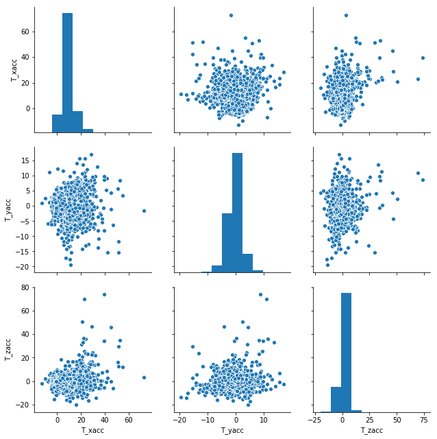

```python
torso_basketball_acc = sns.pairplot(df19p8, height=3, vars=["T_xacc", "T_yacc", 'T_zacc'])
```

We can compare these graphs to what the data looks like while rotations is measured for the subject playing basketball.

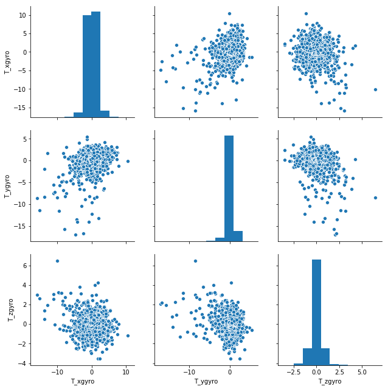

```python
torso_basketball_gyro = sns.pairplot(df19p8, height=3, vars=["T_xgyro", "T_ygyro", 'T_zgyro'])
```

Below, we will compare our graphs to the same subject while he/she remains seated.

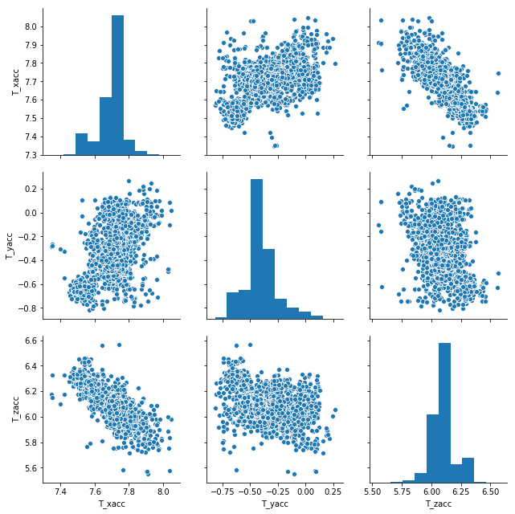

```python
torso_sitting_acc = sns.pairplot(df01p8, height=3, vars=["T_xacc", "T_yacc", 'T_zacc'])
```

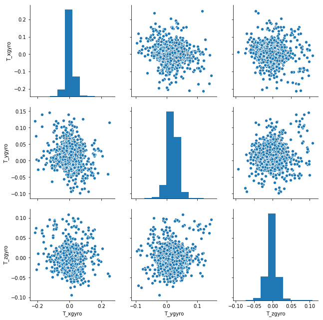

```python
torso_sitting_gyro = sns.pairplot(df01p8, height=3, vars=["T_xgyro", "T_ygyro", 'T_zgyro'])
```

It's interesting to see that in every scatterplot has a highly concentrated center. That center may shift a little, this way or that, but there is always a substantial concentration. This makes me think that there may be clustering due to not specific type of activity (like basketball, or sitting), but something more general such as highly active, or sedentary.

Becaus we are given three axes of measurements, it would be interesting to see some more 3-dimensional modeling. As an example, let's check out what the right leg looks like while walking in a parking lot.

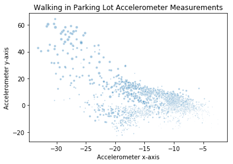

```python
# Visualizing 3-D numeric data with a bubble chart
# length, breadth and size
plt.scatter(X, Y, s=Z,
            alpha=0.4, edgecolors='w')

plt.xlabel('Accelerometer x-axis')
plt.ylabel('Accelerometer y-axis')
plt.title('Walking in Parking Lot Accelerometer Measurements')
```

Here we can see that the acceleration of the z-axis, or the acceleration of the earth, increases when the x-axis is negative and the y-axis is more positive. Very interesting.

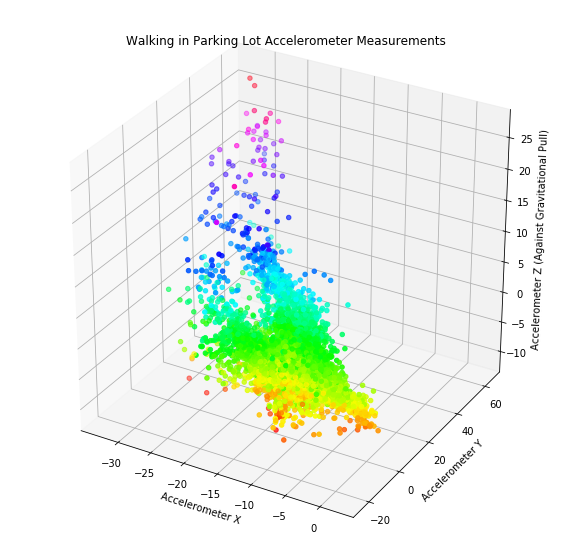

```python
fig = plt.figure(figsize=(10,10))
ax = plt.axes(projection="3d")

z_points = Z
x_points = X
y_points = Y
ax.scatter3D(x_points, y_points, z_points, c=z_points, cmap='hsv');

ax.set_xlabel('Accelerometer X')
ax.set_ylabel('Accelerometer Y')
ax.set_zlabel('Accelerometer Z (Against Gravitational Pull)')

plt.title('Walking in Parking Lot Accelerometer Measurements')
plt.show()
```

So here we see an almost clustering effect again. There is a high concentration in the center or green, if you will. Below I'd like to load the left leg information so we can compare densities between the two legs.

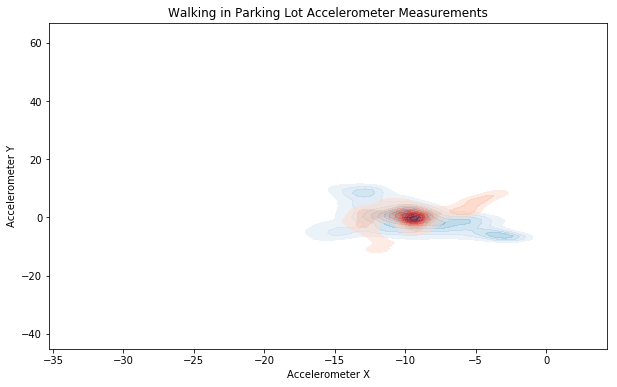

```python
plt.figure(figsize=(10, 6))
ax = sns.kdeplot(X, Y,
                  cmap="Blues", shade=True, shade_lowest=False, alpha=0.5)
ax = sns.kdeplot(X2, Y2,
                  cmap="Reds", shade=True, shade_lowest=False, alpha=0.5)

ax.set_xlabel('Accelerometer X')
ax.set_ylabel('Accelerometer Y')

plt.title('Walking in Parking Lot Accelerometer Measurements')
```

It's interesting to see that there is a lot more variation in the right leg movement that in the left. To make an educated guess, that is probably because more people are right side dominant. Both legs are densest in the exact same spot. Most likely, this is because they have the same neutral position mid-stride.

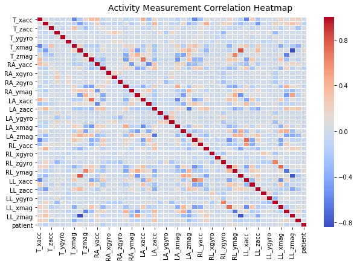

```python
# Correlation Matrix Heatmap
f, ax = plt.subplots(figsize=(10, 6))
corr = result.corr()
hm = sns.heatmap(round(corr,2), annot=False, ax=ax, cmap="coolwarm",fmt='.2f',
                 linewidths=.05)
f.subplots_adjust(top=0.93)

t= f.suptitle('Activity Measurement Correlation Heatmap', fontsize=14)
```

It's also interesting see how all of the features are correlated. The majority of them are fairly neutral.

## Unsupervised Modeling

When running our earlier visualizations, there were obvious concentrations or "clusters", if you will. I think it may be a better method to employing some cluster modeling. Let's begin with a simple KMeans. I've set the cluster PCA to 8 just to test.

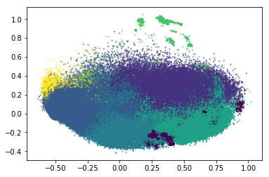

```
Comparing k-means clusters against the data:
activity     1      2      3      4      5      6      7      8      9   \
row_0
0         60000      0  57294      0      4      7      0      5      0
1             0      0   2706      0   3001   3003      0    524      1
2             0  60000      0      0  56580  56866  52735  43850  52421
3             0      0      0      0    411     38   7265  15595   7222
4             0      0      0      0      4      1      0     19    239
5             0      0      0  60000      0      0      0      4      0
6             0      0      0      0      0      0      0      3    114
7             0      0      0      0      0     85      0      0      3

activity     10     11     12     13     14     15     16     17     18     19
row_0
0             0      0    291      0      0      0      0      1      0      0
1             0     24  19093   7800  10055     23     71    232  27127   6918
2         70998  61044    944   8534     12      0   1174      0  15369  17747
3         48102  58798  14343  43537  49280      0   5066      1   2428  30791
4           900    134   5428    120    250  59977  53689  59762    838   1867
5             0      0     66      0      0      0      0      4      4    117
6             0      0  19294      8    403      0      0      0   1972   1338
7             0      0    541      1      0      0      0      0  12262   1222
```

```python
X = result.iloc[:, :46]
y = result.iloc[:, 45]
# Normalize the data.
X_norm = normalize(X)

# Reduce it to two components.
X_pca = PCA(8).fit_transform(X_norm)

# Calculate predicted values.
y_pred = KMeans(n_clusters=8, random_state=42).fit_predict(X)

# Plot the solution.
plt.scatter(X_pca[:, 0], X_pca[:, 1], c=y_pred, s=1.5, alpha=0.5)
plt.show()

# Check the solution against the data.
print('Comparing k-means clusters against the data:')
print(pd.crosstab(y_pred, y))
```

```python
metrics.adjusted_rand_score(y, full_pred)
```

```
0.23276463738347863
```

Well, that didn't work out that well. Our ARS is pretty low at 0.23. Because this is non-flat geometry, and a large dataset, it might be better to use a MeanShift method.

```python
#Divide into training and test sets.
X_train, X_test, y_train, y_test = train_test_split(
    X_norm,
    y,
    test_size=0.9,
    random_state=42)

# Here we set the bandwidth. This function automatically derives a bandwidth
# number based on an inspection of the distances among points in the data.
bandwidth = estimate_bandwidth(X_train, quantile=0.2, n_samples=500)

# Declare and fit the model.
ms = MeanShift(bandwidth=bandwidth, bin_seeding=True)
ms.fit(X_train)

# Extract cluster assignments for each data point.
labels = ms.labels_

# Coordinates of the cluster centers.
cluster_centers = ms.cluster_centers_

# Count our clusters.
n_clusters_ = len(np.unique(labels))

print("Number of estimated clusters: {}".format(n_clusters_))
```

```
Number of estimated clusters: 5
```

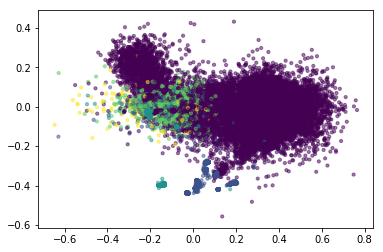

[output not shown]

```python
plt.scatter(X_train[:, 0], X_train[:, 1], c=labels, marker='o', s=10, alpha=0.5,)
plt.show()

print('Comparing the assigned categories to the ones in the data:')
print(pd.crosstab(y_train,labels))
```

So our MeanShift has determined this data has five clusters. Above you can see that the purple cluster overtakes the cluster plot. When thinking back to our dataset, this makes sense. Many of the activities being measured, are fairly inactive or sedentary. This product is logical, but might not be the best classification. Next we'll try an MLP Classifier to see if a neural network does a better job of classifying these activities.

```python
mlp.score(X_norm, y)
```

```
0.8802555555555556
```

Our mlp.score() is 0.88 which isn't half bad, but it would be better to do a GridSearch to determine what hyperparamets are best suited for our dataset. There are some computational power issues at play here because our dataset is rather large, and neural networks in general require a lot of power. Upon initial attempts, convergence warnings were issued so we will need to up our iterations dramatically. The best course of action here is to take a sampling of our data, and execute a GridSearch against that as seen below.

```python
mlp.score(X_samp, y_samp)
```

```
0.998
```

Wow, our mlp score is really high, which usually suggest an overfitting issue. We should use a cross-validation to see how stable our model is.

```python
cross_val_score(mlp, X_samp, y_samp, cv=10)
```

```
array([0.88181818, 0.87735849, 0.87378641, 0.82178218, 0.86      ,
       0.80808081, 0.86734694, 0.83333333, 0.87234043, 0.89247312])
```

Double wow, that is actually pretty stable at first glance. Let's do that GridSearch we talked about to see what tweaking is needed.

```python
param_grid = {
    'hidden_layer_sizes': [(50,50,50), (50,100,50), (100,)],
    'activation': ['tanh', 'relu'],
    'solver': ['sgd', 'adam'],
    'alpha': [0.0001, 0.05],
    'learning_rate': ['constant','adaptive'],
    'max_iter': [10000],
}
clf = GridSearchCV(MLPClassifier(), param_grid, cv=3,
                           scoring='accuracy')
clf.fit(X_samp,y_samp)


print("Best parameters set found on development set:")
print(clf.best_params_)
```

```
Best parameters set found on development set:
{'activation': 'tanh', 'alpha': 0.0001, 'hidden_layer_sizes': (50, 50, 50), 'learning_rate': 'adaptive', 'max_iter': 10000, 'solver': 'adam'}
```

OK, we have our best hyperparameters. Let's fit a new neural network to see if our results improve.

```python
mlp2.score(X_samp, y_samp)
```

```
1.0
```

```python
cross_val_score(mlp2, X_samp, y_samp, cv=10)
```

```
array([0.91818182, 0.93396226, 0.89320388, 0.87128713, 0.85      ,
       0.86868687, 0.89795918, 0.82291667, 0.89361702, 0.94623656])
```

Now our model has a perfect score. Could that be right? Our cross validation in this case is slightly more volatile that before, but still pretty stable. I think it would be a good idea to now take our hyperparameters and run them on the entire dataset to see what we get.

```python
mlp2.score(X_norm, y)
```

```
0.9795444444444444
```

```python
cross_val_score(mlp2, X_norm, y, cv=3)
```

```
array([0.89157857, 0.85798333, 0.88934762])
```